# Project Python Foundations: FoodHub Data Analysis

**Marks: 60**

### Preparation Information

- Developed and Analyzed by: Jerry Gonzalez
- Cohort: November 2023 - Group D

### Context

The number of restaurants in New York is increasing day by day. Lots of students and busy professionals rely on those restaurants due to their hectic lifestyles. Online food delivery service is a great option for them. It provides them with good food from their favorite restaurants. A food aggregator company FoodHub offers access to multiple restaurants through a single smartphone app.

The app allows the restaurants to receive a direct online order from a customer. The app assigns a delivery person from the company to pick up the order after it is confirmed by the restaurant. The delivery person then uses the map to reach the restaurant and waits for the food package. Once the food package is handed over to the delivery person, he/she confirms the pick-up in the app and travels to the customer's location to deliver the food. The delivery person confirms the drop-off in the app after delivering the food package to the customer. The customer can rate the order in the app. The food aggregator earns money by collecting a fixed margin of the delivery order from the restaurants.

### Objective

The food aggregator company has stored the data of the different orders made by the registered customers in their online portal. They want to analyze the data to get a fair idea about the demand of different restaurants which will help them in enhancing their customer experience. Suppose you are hired as a Data Scientist in this company and the Data Science team has shared some of the key questions that need to be answered. Perform the data analysis to find answers to these questions that will help the company to improve the business.

### Data Description

The data contains the different data related to a food order. The detailed data dictionary is given below.

### Data Dictionary

- order_id: Unique ID of the order
- customer_id: ID of the customer who ordered the food
- restaurant_name: Name of the restaurant
- cuisine_type: Cuisine ordered by the customer
- cost: Cost of the order
- day_of_the_week: Indicates whether the order is placed on a weekday or weekend (The weekday is from Monday to Friday and the weekend is Saturday and Sunday)
- rating: Rating given by the customer out of 5
- food_preparation_time: Time (in minutes) taken by the restaurant to prepare the food. This is calculated by taking the difference between the timestamps of the restaurant's order confirmation and the delivery person's pick-up confirmation.
- delivery_time: Time (in minutes) taken by the delivery person to deliver the food package. This is calculated by taking the difference between the timestamps of the delivery person's pick-up confirmation and drop-off information

### Let us start by importing the required libraries

```python
# import system
import sys

# import libraries for data manipulation
import numpy as np
import pandas as pd

# import libraries for data visualization
import warnings
import matplotlib.pyplot as plt
import seaborn as sns
```

### Initialize some basic Panda configurations

```python
# removing the limit for the number of displayed columns
pd.set_option("display.max_columns", None) # To set column limits replace None with a number
# setting the limit for the number of displayed rows
pd.set_option("display.max_rows", 25) # To set row limits replace None with a number
# setting the precision of floating numbers to 2 decimal points
pd.set_option("display.float_format", lambda x: "%.2f" % x)
```

### Load some useful functions

```python
# Purpose: Calculate various discrete statistical values for a specific column in a DataFrame
#
# Prerequisites:
#    Requires the developer to only send data that discrete statistics can safely be calculated for.
#    This function would require more extensive data validation checks and more robust exception handling.
#
# Inputs
#    data   : DataFrame object containing rows and columns of data
#    feature: str representing the column name to run statistics on
#
def calculate_statistics (data, feature):

    # Only calculate and print statistics if the feature is a single column string name and data is a DataFrame
    if isinstance(data,pd.DataFrame) and type(feature) == str:

        # For future, would like to use Describe to pull data types for each column
        # Then only perform the calculations and prints if of type Int64 or Float64

        # Calculate and print various discrete statistical values
        print(f"Discrete Statistics for {feature}\n")
        print(f"Mean              : {data[feature].mean():.6f}")
        print(f"Mode              : {data[feature].mode()[0]}")
        print(f"Median            : {data[feature].median()}")
        print(f"Min               : {data[feature].min()}")
        print(f"Max               : {data[feature].max()}")
        print(f"Standard Deviation: {data[feature].std():.6f}")
        print(f"Percentiles       : \n{data[feature].quantile([.25,.50,.75])}")
```

```python
# Purpose: Create histogram plot to visualize the distribution of continuous numerical data
#      by dividing the data into bins and displaying the frequency of observations within each bin.
#      Histogram is useful for understanding the underlining distribution, shape, central tendency,
#      and spread of the data.
#
# Inputs:
#
#      input_data: DataFrame object containing rows and columns of data
#      feature: str representing the column name to plot a histogram for
#      in_kde: boolean value; True: plot the kde density line; False: do not plot the kde line
#

def histogram(input_data, feature, in_kde=True):

    # Only proceed if the feature is a single column string name and data is a DataFrame
    if isinstance(input_data,pd.DataFrame) and type(feature) == str:

        #stores the x axis left and right buffer size
        buffer=5

        #set the x limits based on the minimum and maximum values for x-axis feature
        xmin_value = int(input_data[feature].min())
        xmax_value = int(input_data[feature].max())
        plt.xlim(xmin_value-buffer,xmax_value+buffer)

        #plot the histogram using the buffersize
        sns.histplot(data=input_data, x=feature, kde=in_kde);

        #set the title, x and y labels
        plt.title('Histogram of '+ feature)
        plt.xlabel(feature)
        plt.ylabel('Frequency')

        plt.show()
```

```python
# Purpose: Create a Boxplot, for a particular column/feature, to visually summarize the distribution
#      of a continuous numerical variable and to identify potential outliers within the data.
#
# Inputs:
#
#      input_data: DataFrame object containing rows and columns of data
#      feature: str representing the column name to plot a count plot graph for
#      in_vert: False (display horizontal); True (display vertically)
#      in_showfliers: True (show the outliers); False (do not show outliers)
#      in_showlabels: True (show boxplot labels for Max,Q3,Median,Q1, and Min); False (do not show labels)
#

def boxplot(input_data,feature,in_vert=False,in_showfliers=False, in_showlabels=True):

    #label translater key
    label_translator = {'caps 0': 'Min', 'caps 1': 'Max', 'whiskers 0': 'Q1', 'whiskers 1': 'Q3','medians 0':'Median', 'boxes 0':'Box'}

    # Only proceed if data is a DataFrame
    if isinstance(input_data,pd.DataFrame):

        ax = plt.boxplot(df[feature], vert=in_vert,showfliers=in_showfliers)

        plt.title('Boxplot of '+ feature)
        plt.xlabel(feature)

        # Revisit this later to figure out a more robust way to get the min x value for labels.
        # Right now, the median has the smallest x value when in vert mode
        min_x = ax['medians'][0].get_xydata()[0][0] - .05;

        #show labels for the main boxplot lines (e.g, Max Line, Q1, Q3, Min Line)
        for i in ax.keys():
            for index,line in enumerate(ax[i]):

                # for some reason boxes is redundant for Q1. Filter this value out. We're also not interested in
                # labels for outliers
                if (i != 'boxes' and i != 'fliers'):
                    line_x,line_y=line.get_xydata()[0]

                    #if needed and in vertical mode, show the key boxplot labels
                    #revisit later to get labels working in horizontal mode
                    if (in_showlabels == True and in_vert == True):
                        label_key = f"{i} {index}"
                        label = f"{label_translator[label_key]}:{line_y:.2f}"
                        plt.text(min_x,line_y,label,ha='right',va='center',color='blue',fontsize=9)

        plt.show()
```

```python
# Purpose: Create Boxplot for multiple variables (x being a categorical value)
#
# Inputs:
#
#     in_data: DataFrame object containing rows and columns of data
#     x_feature: str representing the column name for the x-axis (categorical data)
#     y_feature: str representing the column name for the y-axis
#
def multi_boxplot (in_data, x_feature, y_feature):

    # Only proceed if the features is a single column string name and data is a DataFrame
    if isinstance(in_data,pd.DataFrame) and type(x_feature) == str and type(y_feature) == str:

        # visualizing the relationship between two featgures
        plt.figure(figsize=(12, 5))
        sns.boxplot(data=df, x=x_feature, y=y_feature, showmeans=True)
        plt.xticks(fontsize=15)
        plt.yticks(fontsize=15)
        plt.xticks(rotation='vertical')
        plt.xlabel(x_feature, fontsize=15)
        plt.ylabel(y_feature, fontsize=15);

        plt.show()
```

```python
# Purpose: Create a countplot to visualize the distribution of categorical variables.
#
# Inputs:
#
#     input_data: DataFrame object containing rows and columns of data
#     feature: str representing the column name to plot a count plot graph for
#     hue_type: used to add additional categorical data to plot
#
# Notes:
#     data.loc[data[feature]>x,'Type'].value_counts()
#     data.loc[data[feature]>x].shape
#
def countplot(input_data, feature, hue_type=None):
    # Only proceed if the feature is a single column string name and data is a DataFrame
    if isinstance(input_data,pd.DataFrame) and type(feature) == str:
        if (hue_type is None):
            sns.countplot(data=input_data, x=feature)
        else:
            sns.countplot(data=input_data, x=feature,hue=hue_type)

        plt.show();
```

```python
# Purpose: Create a countplot; used to visualize counts for categorical data
#
# Inputs:
#
#     input_data: DataFrame object containing rows and columns of data
#     feature: str representing the column name to plot a count plot graph for (category column)
#     show_perc: value from [0,1] indicating the top % values to show in the countplot
#     label_count: True (show count labels); False (show percentage labels)
#
def countplot (input_data, feature, show_perc=1.0, label_count=True):
    if isinstance(input_data,pd.DataFrame) and type(feature) == str:

        #Set the figure size. However, revist this later to see if there is a robust way to increase the
        #figure size based on the number of x-axis labels.
        plt.figure(figsize=(10, 6))

        #Perform a total counts, which sorts the list in descending order. Then grab the list of columns
        order_cols = input_data[feature].value_counts().index

        #Use the percentage value to determine how many of the top columns to show
        num_to_show = int(len(order_cols)*show_perc)

        #Grab the top columns to show in the count plot
        cols_to_show = input_data[feature].value_counts().nlargest(num_to_show).index

        #plot the top columns
        cp=sns.countplot(data=input_data,x=feature,order=cols_to_show)

        #rotate x labels for better readability
        plt.xticks(rotation=90)

        #set the title
        plt_title = f"Countplot for the top {show_perc*100}% {feature} values"
        plt.title(plt_title)

        # Apply some simple label formatting; remove the underscores and replace with a blank space
        cp.set_xlabel(feature.replace('_', ' ').title(), fontsize=15)

        #show values for each bar/patch. The labels will either be numerical values or percentages.
        for p in cp.patches:

            total_values = len(input_data[feature])

            #show count labels
            if label_count == True:
                label = p.get_height()
            else:
                # show percentage label
                label = "{:.1f}%".format(100 * p.get_height() / total_values)

            cp.annotate(
                label,
                (p.get_x()+p.get_width()/2.,p.get_height()),
                ha='center',
                va='center',
                xytext=(0,5), # set the label offset above the bar
                textcoords='offset points'
            )

        plt.show()
```

```python
# Purpose: Create a scatterplot; typically used to visualize the relationship between two continuous variables.
#     It represents individual data points as dots on a two-dimensional plane, with one variable plotted on
#     the x-axis and the other variable plotted on the y-axis.
#
# Inputs:
#
#     input_data: DataFrame object containing rows and columns of data
#     x_feature: str representing the x axis to plot (numberical column)
#     y_feature: str representing the y axis to plot (numberical column)
#
def scatterplot (input_data, x_feature, y_feature):

    #do some basic validation on the input parameters and then create the scatterplot
    if isinstance(input_data,pd.DataFrame) and type(x_feature) == str and type(y_feature)==str:
        plt.figure(figsize=(10,5))
        sns.scatterplot(data=input_data,x=x_feature,y=y_feature)

        #set the title
        plt_title = f"Scatterplot: {x_feature} vs {y_feature}"
        plt.title(plt_title)

        plt.show()
```

```python
# Purpose: Create a linear regression plot. The lmplot is used to visualize a scatterplot along with the
# linear regression line (best linear fit).
#
# Inputs:
#
#     input_data: DataFrame object containing rows and columns of data
#     x_feature: str representing the x axis to plot (numberical column)
#     y_feature: str representing the y axis to plot (numberical column)
#     input_height: height of the plot
#     input_aspect: represents the ratio of the height to the width of each facet. can be set to "auto"
#
# Helpful tip:
#      input_data[[col,col2]].corr() - Calculates the correlation between 2 columns
#
def lmplot (input_data, x_feature, y_feature, input_height=5, input_aspect=2):

    #do some basic validation on the input parameters and then create the linear regression plot
    if isinstance(input_data,pd.DataFrame) and type(x_feature) == str and type(y_feature)==str:

        #supress the tight_layout warning
        with warnings.catch_warnings():
            warnings.filterwarnings("ignore",category=UserWarning,module="seaborn")

            #plot the linear reqression plot
            sns.lmplot(data=input_data,x=x_feature,y=y_feature,height=input_height,aspect=input_aspect)

            #stores the x axis buffer
            buffer=5

            #set the x limits based on the minimum and maximum values for x-axis feature
            xmin_value = input_data[x_feature].min()
            xmax_value = input_data[x_feature].max()
            plt.xlim(xmin_value-buffer,xmax_value+buffer)

            #set the title
            plt_title = f"Linear Regression Plot: {x_feature} vs {y_feature}"
            plt.title(plt_title)

            plt.show()
```

```python
# Purpose: Create a catplot; supports multivariate analysis of 2+ categorical features; creates a grid
#     of scatterplots
#
# Inputs:
#
#     in_data: DataFrame object containing rows and columns of data
#     x_feature: list representing the column names to plot a histogram plot graph for each categorical column
#     y_feature: list representing the column names to plot a histogram plot graph for each numerical column
#     in_hue: str representing the hue column to display
#     in_col: str representing the categorical column to create multiple plots for
#     in_kind: str representing the kind of plot.  Valid values are: box, swarm, strip, violin
#     in_pallete: str representing the pallete. Valid values are: deep, muted, bright, pastel, dark, colorblind
#     in_xorder:
#
def catplot (in_data,x_feature,y_feature,in_hue=None,in_col=None,in_kind='box',in_palette='bright',in_xorder=None):

    #do some basic validation on the input parameters and then create the scatterplot
    if isinstance(in_data,pd.DataFrame):

        #supress the tight_layout warning
        with warnings.catch_warnings():
            warnings.filterwarnings("ignore",category=UserWarning,module="seaborn")

            # set the number of graphs per row
            col_wrap_value=3

            # call countplot with various different optional values like: hue and col input parameters
            if (in_hue is None and in_col is None):
                sns.catplot(data=in_data,x=x_feature,y=y_feature,kind=in_kind, col_wrap=col_wrap_value,legend=True)
            elif (in_hue is None and in_col != None): # if col value is provided, use that in catplot call
                sns.cattplot(data=in_data,x=x_feature,y=y_feature,col=in_col,kind=in_kind,col_wrap=col_wrap_value,legend=True)
            elif (in_hue != None and in_col is None): # if hue value is provided, use that in catplot call
                sns.catplot(data=in_data,x=x_feature,y=y_feature,hue=in_hue,kind=in_kind,col_wrap=col_wrap_value,legend=True)
            else: # if both the hue and col values are provided, use them both in the catplot call
                sns.catplot(data=in_data,x=x_feature,y=y_feature,hue=in_hue, col=in_col,kind=in_kind,col_wrap=col_wrap_value,legend=True)

            #rotate x labels for better readability
            plt.xticks(rotation=90)

            #set the order of the x labels
            if (in_xorder is not None):
                plt.gca().set_xticklabels(in_xorder)

            plt.show()
```

```python
# Purpose: Create a pairplot; supports bivariate analysis of 2+ numerical features
#
# Inputs:
#
#     in_data: DataFrame object containing rows and columns of data
#
def pairplot (in_data):

    #do some basic validation on the input parameters and then create the scatterplot
    if isinstance(in_data,pd.DataFrame):

        #supress the tight_layout warning
        with warnings.catch_warnings():
            warnings.filterwarnings("ignore",category=UserWarning,module="seaborn")

            # Select only the numerical columns
            numeric_columns = in_data.select_dtypes(include=np.number).columns.tolist()

            sns.pairplot(data=in_data[numeric_columns])
            plt.show()
```

```python
# Purpose: Create a heatmap which supports multivariate analysis of 2+ numerical features. Heatmaps are
#     useful for identifying correlations between 2 or more variables.
#
# Inputs:
#
#     input_data: DataFrame object containing rows and columns of data
#
def heatmap (input_data):
    if isinstance(input_data,pd.DataFrame): #and type(feature) == str:
        plt.figure(figsize=(10,8))

        # Select only the numerical columns
        numeric_columns = input_data.select_dtypes(include=np.number)

        sns.heatmap(numeric_columns.corr(),annot=True,cmap='Spectral',vmin=-1,vmax=1)
        plt.show()
```

### Understanding the structure of the data

```python
# uncomment and run the following lines for Google Colab
# from google.colab import drive
# drive.mount('/content/drive')
```

```python
# read the data
df = pd.read_csv('foodhub_order.csv')

# returns the first 5 rows
df.head()
```

|  | order_id | customer_id | restaurant_name | cuisine_type | cost_of_the_order | day_of_the_week | rating | food_preparation_time | delivery_time |
| --- | --- | --- | --- | --- | --- | --- | --- | --- | --- |
| 0 | 1477147 | 337525 | Hangawi | Korean | 30.75 | Weekend | Not given | 25 | 20 |
| 1 | 1477685 | 358141 | Blue Ribbon Sushi Izakaya | Japanese | 12.08 | Weekend | Not given | 25 | 23 |
| 2 | 1477070 | 66393 | Cafe Habana | Mexican | 12.23 | Weekday | 5 | 23 | 28 |
| 3 | 1477334 | 106968 | Blue Ribbon Fried Chicken | American | 29.20 | Weekend | 3 | 25 | 15 |
| 4 | 1478249 | 76942 | Dirty Bird to Go | American | 11.59 | Weekday | 4 | 25 | 24 |

#### Observations:

The DataFrame has 9 columns as mentioned in the Data Dictionary. Data in each row corresponds to the order placed by a customer.

### **Question 1:** How many rows and columns are present in the data? [0.5 mark]

```python
# Determine the number of rows and columns
df.shape
print (f"There are {df.shape[0]} rows and {df.shape[1]} columns.")
```

```
There are 1898 rows and 9 columns.
```

#### Observations:

- *There are 1898 rows and 9 columns in the foodhub dataset.*

### **Question 2:** What are the datatypes of the different columns in the dataset? (The info() function can be used) [0.5 mark]

```python
# Use info() to print a concise summary of the DataFrame
df.info()
```

```
<class 'pandas.core.frame.DataFrame'>
RangeIndex: 1898 entries, 0 to 1897
Data columns (total 9 columns):
 #   Column                 Non-Null Count  Dtype
---  ------                 --------------  -----
 0   order_id               1898 non-null   int64
 1   customer_id            1898 non-null   int64
 2   restaurant_name        1898 non-null   object
 3   cuisine_type           1898 non-null   object
 4   cost_of_the_order      1898 non-null   float64
 5   day_of_the_week        1898 non-null   object
 6   rating                 1898 non-null   object
 7   food_preparation_time  1898 non-null   int64
 8   delivery_time          1898 non-null   int64
dtypes: float64(1), int64(4), object(4)
memory usage: 133.6+ KB
```

#### Observations:

- The data type of the `order_id`, `customer_id`, `food_preparation_time`, and `delivery_time` columns are of integer type; since they are representing keys and time values.
- The data type of the `cost_of_the_order` column is of float64; since it is representing dollar and cents.
- The data type of the `restaurant_name`, `cuisine_type`, `day_of_the_week`, and `rating` columns are of object type; since they are storing character strings.
  - Note: The `rating` column stores numerical ratings and should be of integer type. However, when a rating is not provided a string of "Not given" is stored. This is an indication that this data may need data cleansing or may need appropriate handling when performing numerical or statistical calculations on this field.

### **Question 3:** Are there any missing values in the data? If yes, treat them using an appropriate method. [1 mark]

```python
#Check if the data has any null values
df.isnull().any()

#As an extra check, determine if the data has any duplicate rows
#df.duplicated().sum()
```

```
order_id                 False
customer_id              False
restaurant_name          False
cuisine_type             False
cost_of_the_order        False
day_of_the_week          False
rating                   False
food_preparation_time    False
delivery_time            False
dtype: bool
```

#### Observations:

- There are no missing values in any of the column data. Additionally, according to the df.info() command there are no missing values.
- However, during further analysis (below), it was determined that sometimes the rating has a value of "Not Given" and may be characterized as missing values. The Rating univariate analysis below will dive deeper into this analysis.

### **Question 4:** Check the statistical summary of the data. What is the minimum, average, and maximum time it takes for food to be prepared once an order is placed? [2 marks]

```python
# Check the statistical summary
df.describe().T
```

|  | count | mean | std | min | 25% | 50% | 75% | max |
| --- | --- | --- | --- | --- | --- | --- | --- | --- |
| order_id | 1898.00 | 1477495.50 | 548.05 | 1476547.00 | 1477021.25 | 1477495.50 | 1477969.75 | 1478444.00 |
| customer_id | 1898.00 | 171168.48 | 113698.14 | 1311.00 | 77787.75 | 128600.00 | 270525.00 | 405334.00 |
| cost_of_the_order | 1898.00 | 16.50 | 7.48 | 4.47 | 12.08 | 14.14 | 22.30 | 35.41 |
| food_preparation_time | 1898.00 | 27.37 | 4.63 | 20.00 | 23.00 | 27.00 | 31.00 | 35.00 |
| delivery_time | 1898.00 | 24.16 | 4.97 | 15.00 | 20.00 | 25.00 | 28.00 | 33.00 |

### **Question 5:** How many orders are not rated? [1 mark]

```python
# Write the code here
not_rated_count=df[df.rating == "Not given"]["order_id"].count()
print(f"There are {not_rated_count} orders not rated.")
```

```
There are 736 orders not rated.
```

#### Observations:

- 736 orders out of a total of 1898 orders are not rated.

### Exploratory Data Analysis (EDA)

### **Question 6:** Explore all the variables and provide observations on their distributions. (Generally, histograms, boxplots, countplots, etc. are used for univariate exploration.) [9 marks]

```python
# order_id analysis
# order_id is considered a unique key and therefore it does not make sense to perform the typical univariate analysis.
# However, since it is a key, it is important to determine how many orders there are and if there are any duplicate orders.

# calculate the number oforders
total_orders = df['order_id'].count()

# calculate the number of unique orders
unique_orders = df['order_id'].nunique()

# calculate the number of duplicate orders
duplicate_orders = df['order_id'].duplicated().sum()

#print out the order information
print(f"The total number of orders are {total_orders}.")
print(f"The number of unique orders are {unique_orders}.")
print(f"The number of duplicate orders are {duplicate_orders}.")
```

```
The total number of orders are 1898.
The number of unique orders are 1898.
The number of duplicate orders are 0.
```

#### Observations:

- order_id is a unique key and therefore it doesn't make sense to perform the typical univariate analysis on it.
- There are a total of 1898 orders and there are no duplicate values in this key field (which is good).

```python
# customer_id is considered a key and therefore it does not make sense to perform the typical univariate analysis.
# However, since it is a key, it may be important to determine how many orders each customer placed.

selected_column='customer_id'

# calculate the number of customers
total_customers = df[selected_column].count()

# calculate the number of unique customers
unique_customers = df[selected_column].nunique()

# calculate the number of duplicate customer orders
duplicate_customers = df[selected_column].duplicated().sum()

#print out the order information
print(f"\nThe total number of orders are {total_customers}.")
print(f"The number of unique customers are {unique_customers}.")
print(f"There were {duplicate_customers} orders that came from {unique_customers} customers ordering more than once.")

# Tally the number of orders received by each restaurant and then sort in descending order.
# Technically, this is bivariate analysis, but it makes sense to the flow to show it here.
customer_data = df.groupby(['customer_id'])["order_id"].count().to_frame().reset_index()
customer_data.columns = ['Customer ID', 'Number of Orders']
customer_data = customer_data.sort_values(by='Number of Orders',ascending=False)
customer_data.head(15)
```

```
The total number of orders are 1898.
The number of unique customers are 1200.
There were 698 orders that came from 1200 customers ordering more than once.
```

|  | Customer ID | Number of Orders |
| --- | --- | --- |
| 116 | 52832 | 13 |
| 84 | 47440 | 10 |
| 333 | 83287 | 9 |
| 839 | 250494 | 8 |
| 216 | 65009 | 7 |
| 329 | 82041 | 7 |
| 847 | 259341 | 7 |
| 870 | 276192 | 7 |
| 171 | 60052 | 6 |
| 519 | 115213 | 6 |
| 869 | 275689 | 6 |
| 418 | 97079 | 6 |
| 487 | 107909 | 6 |
| 426 | 97991 | 6 |
| 512 | 114085 | 5 |

#### Observations:

- custonmer_id is a key and therefore it doesn't make sense to perform the typical univariate analysis on it.
- There are a total of 1898 orders that are placed by only 1200 customers.
- Technically, this is considered bivariate analysis, but for data analysis flow it makes sense to list here.
  - The following table lists the top ordering customers who ordered six (6) or more times.

| Customer ID | Number of Orders |
| --- | --- |
| 52832 | 13 |
| 47440 | 10 |
| 83287 | 9 |
| 250494 | 8 |
| 65009 | 7 |
| 82041 | 7 |
| 259341 | 7 |
| 276192 | 7 |
| 60052 | 6 |
| 115213 | 6 |
| 275689 | 6 |
| 97079 | 6 |
| 107909 | 6 |
| 97991 | 6 |

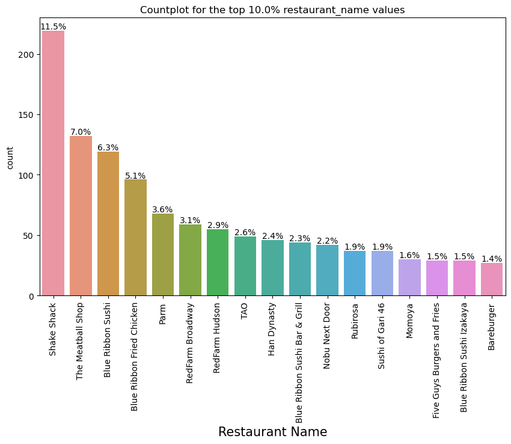

```
Number of restaurants: 178
```

```python
#restaurant name Analysis

#Create histogram plot for the top 10% restaurants
countplot(df,'restaurant_name',show_perc=.10,label_count=False)

#Print the total number of unique restaurants
print(f"Number of restaurants: {df['restaurant_name'].nunique()}")
```

#### Observations:

- There are **178** restaurants.
- The Top 5 restaurants receiving the most orders are as follows:
  - Shake Shack
  - The Meatball Shop
  - Blue Ribbon Sushi
  - Blue Ribbon Fried Chicken
  - Parm

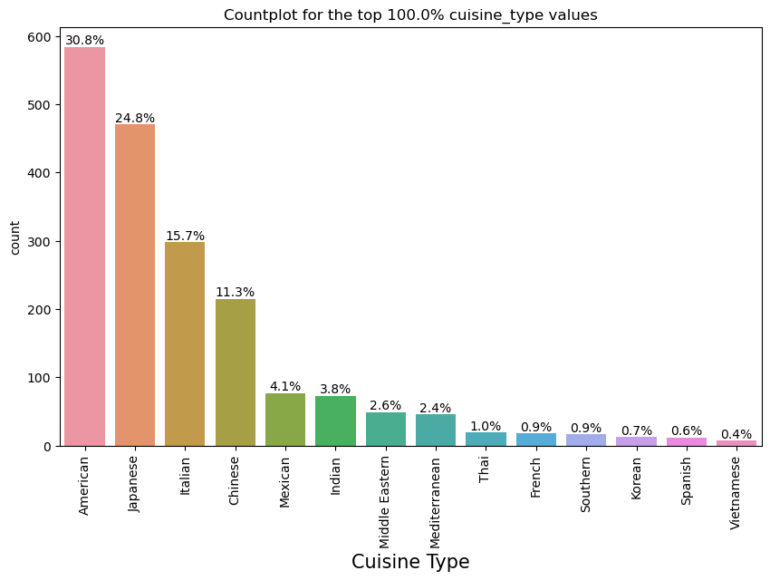

```
Number of cuisine types: 14
```

```python
# cuisine_type univariate analysis

# Create histogram plot for all cuisine types
countplot(df,'cuisine_type', show_perc=1.0, label_count=False)

#Print the total number of unique cuisine types
print(f"Number of cuisine types: {df['cuisine_type'].nunique()}")
```

#### Observations:

- There are 14 cuisine types.
- The top four cuisine types (American, Japanese, Italian, and Chinese) account for 82.6% of the orders.

```
Discrete Statistics for cost_of_the_order

Mean              : 16.498851
Mode              : 12.18
Median            : 14.14
Min               : 4.47
Max               : 35.41
Standard Deviation: 7.483812
Percentiles       :
0.25   12.08
0.50   14.14
0.75   22.30
Name: cost_of_the_order, dtype: float64
```

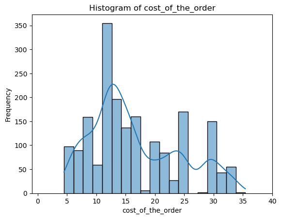

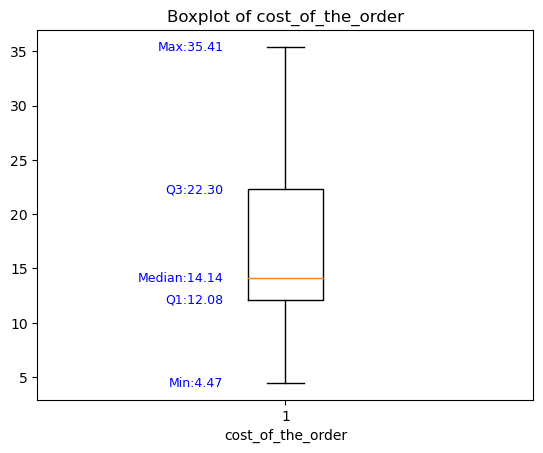

```python
selected_column = 'cost_of_the_order'

#calculate univariate statistics
calculate_statistics(df,selected_column)

#show histogram for cost_of_the_order
histogram(df,selected_column)

#show boxplot for cost_of_the_order
boxplot(df,selected_column,in_vert=True, in_showfliers=False,in_showlabels=True)
```

#### Observations

- Most orders (around 350) cost around `$12-$13`.
- There are around 150 orders costing around `$29-$30`
- The median cost of order is `$14.14`
- 75% of orders cost `$22.30` or less.
- The difference between the minimum and maximum is `$30.94`
- The data is slightly right skewed.

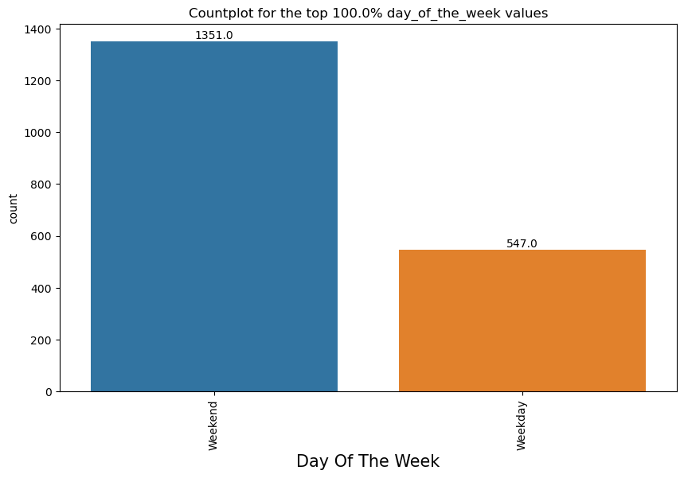

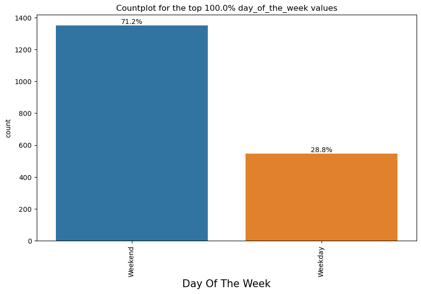

```
Number of day of the week values: 2
```

```python
# day_of_the_week univariate analysis

#Create a countplot for day of the week; show counts
countplot(df,'day_of_the_week',label_count=True)

#Create a countplot for day of the week; show percentages
countplot(df,'day_of_the_week',label_count=False)

#Print the total number of unique day of the week values
print(f"Number of day of the week values: {df['day_of_the_week'].nunique()}")
```

#### Observations:

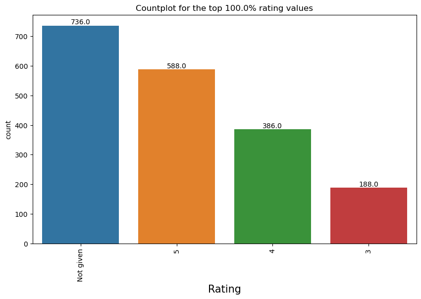

```
Number of rating values: 4
```

```python
# rating
countplot(df,'rating')

#Print the total number of unique rating values
print(f"Number of rating values: {df['rating'].nunique()}")
```

#### Observation

- There are four (4) unique rating values.
- 736 ratings were not given
- Most restaurants received a rating of 5 or 4.
- No restaurants received below a 3 rating.
  - Note: May indicate a need to ensure the application is working and allows ratings of 1 and 2.

```
Discrete Statistics for food_preparation_time

Mean              : 27.371970
Mode              : 21
Median            : 27.0
Min               : 20
Max               : 35
Standard Deviation: 4.632481
Percentiles       :
0.25   23.00
0.50   27.00
0.75   31.00
Name: food_preparation_time, dtype: float64
```

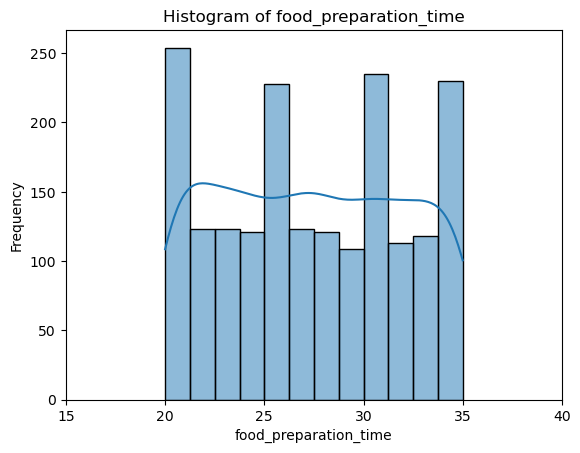

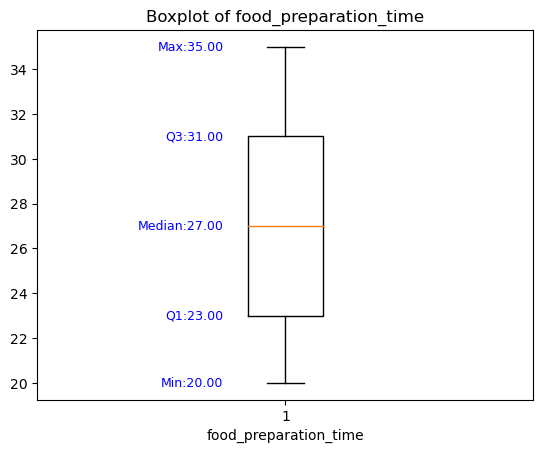

```python
selected_column = 'food_preparation_time'

#calculate univariate statistics
calculate_statistics(df,selected_column)

#show histogram for food_preparation_time
histogram(df,selected_column)

#show boxplot for food_preparation_time
boxplot(df,selected_column,in_vert=True, in_showfliers=True,in_showlabels=True)
```

#### Observations:

- The food_preparation_time data closely follows a **uniform** distribution between the 20 and 35 minutes.
- 75% of the food preparation times were 31 min and under.
- The median food preparation time is 27 minutes.
- The difference between the min and max food preparation times is 15 minutes.

```
Discrete Statistics for delivery_time

Mean              : 24.161749
Mode              : 24
Median            : 25.0
Min               : 15
Max               : 33
Standard Deviation: 4.972637
Percentiles       :
0.25   20.00
0.50   25.00
0.75   28.00
Name: delivery_time, dtype: float64
```

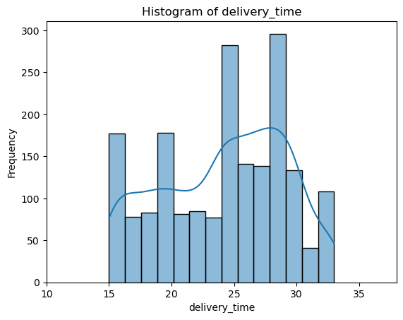

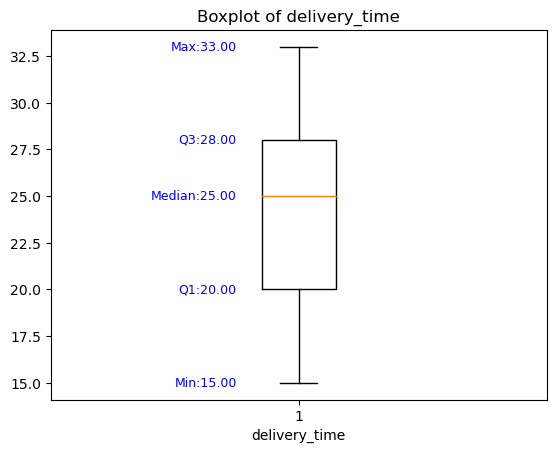

```python
selected_column = 'delivery_time'

#calculate univariate statistics
calculate_statistics(df,selected_column)

#show histogram for delivery_time
histogram(df,selected_column)

#show boxplot for delivery_time
boxplot(df,selected_column,in_vert=True, in_showfliers=True,in_showlabels=True)
```

#### Observations:

- Minimum delivery time is 15 minutes.
- Maximum delivery time is 33 minutes.
- 75% of the delivery times were 28 min and under.
- The median delivery time is 25 minutes.
- The data appears to be slightly left-skewed.

### **Question 7**: Which are the top 5 restaurants in terms of the number of orders received? [1 mark]

```python
# Tally the number of orders received by each restaurant and then sort in descending order.
restaurant_data = df.groupby(["restaurant_name"])["order_id"].count().to_frame().reset_index()
restaurant_data.columns = ['Restaurant', 'Number of Orders']
df_restaurant = restaurant_data.sort_values(by='Number of Orders',ascending=False)
df_restaurant.head(5)
```

|  | Restaurant | Number of Orders |
| --- | --- | --- |
| 136 | Shake Shack | 219 |
| 153 | The Meatball Shop | 132 |
| 21 | Blue Ribbon Sushi | 119 |
| 20 | Blue Ribbon Fried Chicken | 96 |
| 109 | Parm | 68 |

#### Observations:

- The top five (5) restaurants in terms of number of orders received are as follows:
  > 1. Shake Shack
  > 2. The Meatball Shop
  > 3. Blue Ribbon Sushi
  > 4. Blue Ribbon Fried Chicken
  > 5. Parm

### **Question 8**: Which is the most popular cuisine on weekends? [1 mark]

```python
# Add a column 'ordered_on_weekend' that is 1 if day_of_order = 'Weekend' else 0
df["ordered_on_weekend"] = df["day_of_the_week"].apply(
    lambda x: 1 if x == "Weekend" else 0
)

df.head(25)
df['ordered_on_weekend'].value_counts()

# Tally the number of weekend orders for each cuisine type and sort in descending order.
df_copy = df.groupby(["cuisine_type"])["ordered_on_weekend"].sum().to_frame().reset_index()
df_copy.columns = ['Cuisine Type', 'Number of Weekend Orders']
df_copy.sort_values(by='Number of Weekend Orders',ascending=False)
```

|  | Cuisine Type | Number of Weekend Orders |
| --- | --- | --- |
| 0 | American | 415 |
| 5 | Japanese | 335 |
| 4 | Italian | 207 |
| 1 | Chinese | 163 |
| 8 | Mexican | 53 |
| 3 | Indian | 49 |
| 7 | Mediterranean | 32 |
| 9 | Middle Eastern | 32 |
| 12 | Thai | 15 |
| 2 | French | 13 |
| 6 | Korean | 11 |
| 10 | Southern | 11 |
| 11 | Spanish | 11 |
| 13 | Vietnamese | 4 |

#### Observations:

- The top four (4) cuisines in terms of number of weekend orders are as follows:
  > 1. American
  > 2. Japanese
  > 3. Italian
  > 4. Chinese

### **Question 9**: What percentage of the orders cost more than 20 dollars? [2 marks]

```python
#initialize variables
count_greater_than_20=0
total_orders=0

#Iterate through each row/order
for index, row in df.iterrows():

    #increment the total order counter; used to calculate %
    total_orders += 1

    #grab the cost of the order
    cost_of_order = row['cost_of_the_order']

    #if the cost of the order is greater than 20 then count it
    if cost_of_order > 20:
        count_greater_than_20 += 1

print('Total orders costing more than $20:',count_greater_than_20)
print('Total number of orders:',total_orders)
print('% of orders more than $20: {}%'.format (round(count_greater_than_20/total_orders*100,2)))
```

```
Total orders costing more than $20: 555
Total number of orders: 1898
% of orders more than $20: 29.24%
```

#### Observations:

- % of orders costing more than $20 is 29.24%

### **Question 10**: What is the mean order delivery time? [1 mark]

```python
# Calculate the mean order delivery time
df.describe()

print(f"The mean order delivery time is: {df['delivery_time'].mean():.6f} minutes.")
```

```
The mean order delivery time is: 24.161749 minutes.
```

#### Observations:

- The mean order delivery time is 24.161749 minutes. Note: The mean value was also taken from the delivery time univariate analysis.

### **Question 11:** The company has decided to give 20% discount vouchers to the top 3 most frequent customers. Find the IDs of these customers and the number of orders they placed. [1 mark]

```python
# For each customer tally up their number of orders
# Sort the list by customer total orders in descending order
# Identify the top 3 customers
customer_data = df.groupby(["customer_id"])["order_id"].count().to_frame().reset_index()
customer_data.columns = ['Customer ID', 'Number of Orders']
customer_sorted=customer_data.sort_values(by='Number of Orders',ascending=False)
customer_sorted.head(3)
```

|  | Customer ID | Number of Orders |
| --- | --- | --- |
| 116 | 52832 | 13 |
| 84 | 47440 | 10 |
| 333 | 83287 | 9 |

#### Observations:

Top 3 Most Frequent Customers

| Customer ID | Number of Orders |
| --- | --- |
| 52832 | 13 |
| 47440 | 10 |
| 83287 | 9 |

### **Question 12**: Perform a multivariate analysis to explore relationships between the important variables in the dataset. (It is a good idea to explore relations between numerical variables as well as relations between numerical and categorical variables) [10 marks]

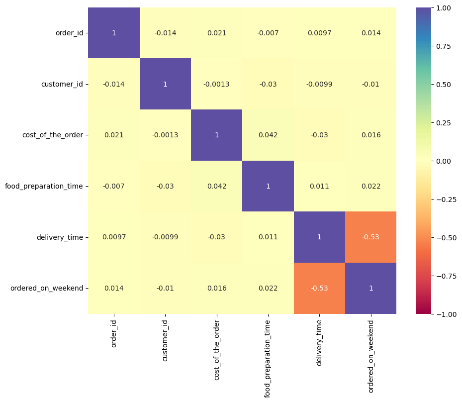

```python
# Start off with a heatmap to determine correlations between numerical features.
# Note: ordered_on_weekend column was added; 1 signifies the order was placed on the weekend; 0 signifies the
# order placed during the week.
heatmap(df)
```

#### Observartions:

- There does not appear to be any strong positive correlations between the numeric values.
- The ordered_on_weekend column is really a categorical value (non-continuous value). However, there appears to be a moderate negative correlation between ordered_on_weekend and delivery_time. That is, ordering on the weekend appears to show a decreased delivery time.

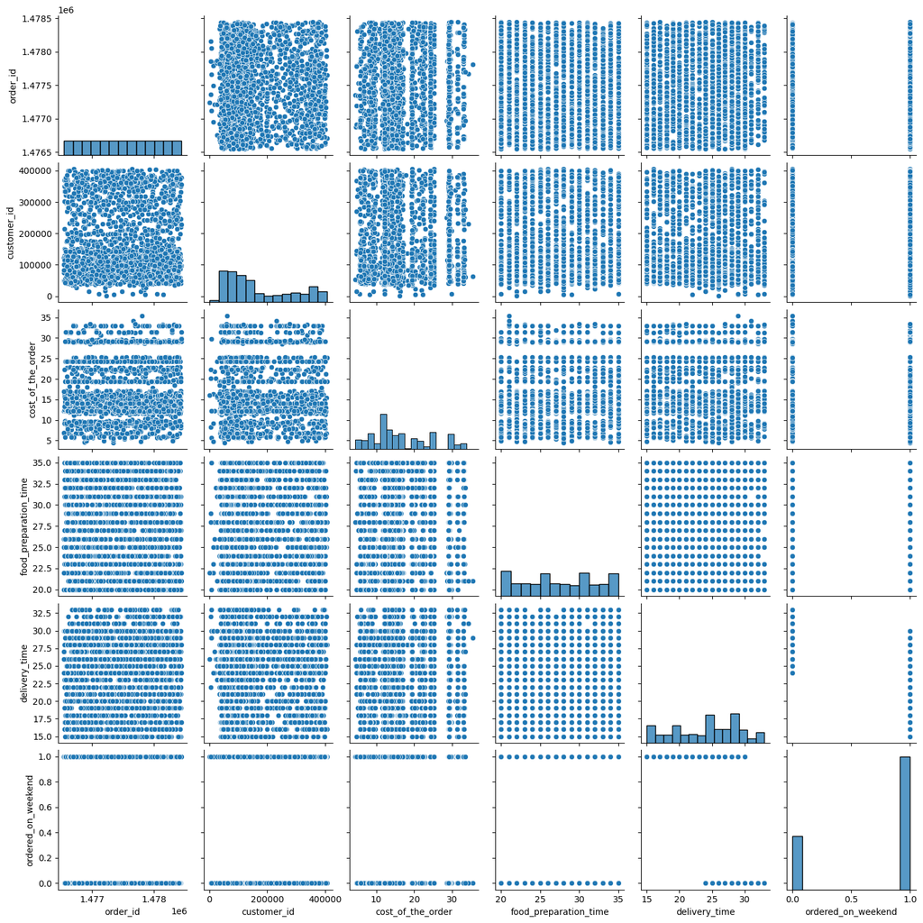

```python
# Run a pairplot to look for coorellations among numeric values
pairplot(df)
```

#### Observations:

- The HeatMap showed no significant correlations and therefore, the pairplot was not needed.
- Implemented for learning purposes only and to visually verify why the heatmap showed no coorelations.
  - Note: In a real-world situation, would have dropped this plot from this particular analysis.
- The pairplot along with the heatmap showed no significant correlations between numerical values.

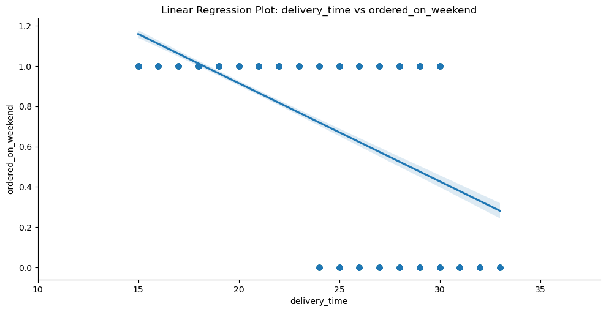

```python
#plot a linear-regression plot
lmplot(df,"delivery_time", "ordered_on_weekend")
```

#### Observations:

- Implemented for learning purposes only
  - Note: In a real-world situation, would have dropped this plot from this particular analysis.
- A value of 1 (indicates ordered on weekend) showes a slightly less delivery time as compared to a weekday order.
- It's possible that is due to increased orders; which may translate to increased delivery drivers.

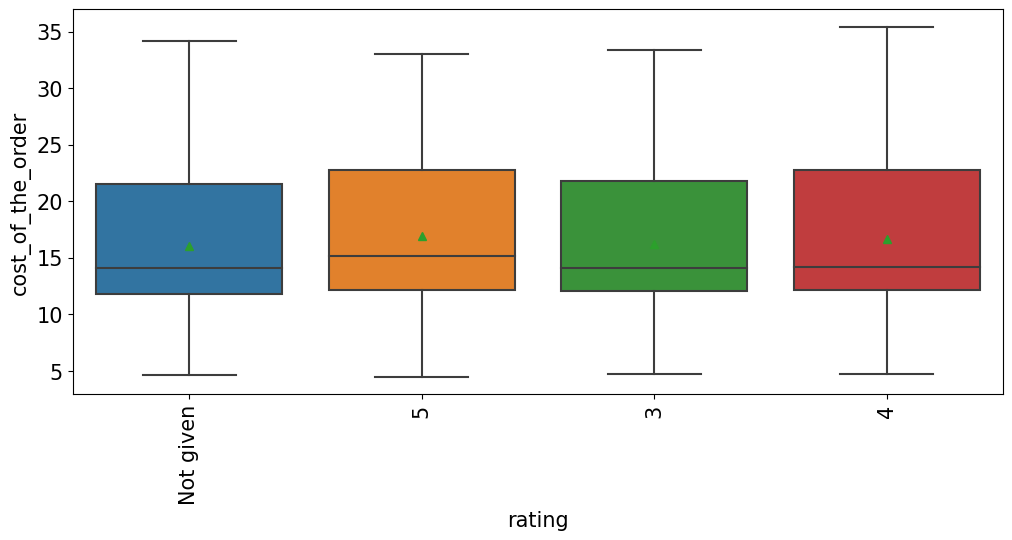

```python
# visualizing the relationship between ratings and cost of the order
multi_boxplot(in_data=df,x_feature="rating", y_feature="cost_of_the_order")
```

#### Observations:

- There appears to be no visual indicator that cost of the order impacts the rating.

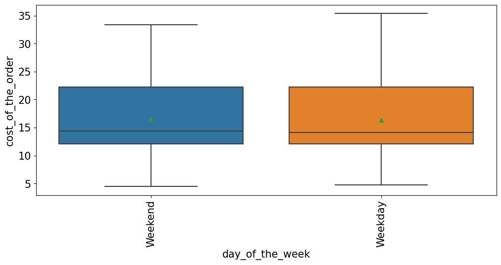

```python
# visualizing the relationship between day_of_the_week and cost of the order
multi_boxplot(in_data=df,x_feature="day_of_the_week", y_feature="cost_of_the_order")
```

#### Observations:

- No indicators that the day of the week significantly impacts the cost of the orders.

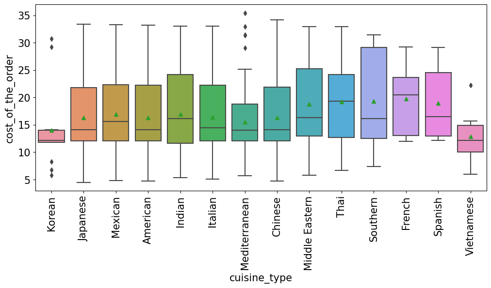

```python
# visualizing the relationship between cuisine_type and cost of the order
multi_boxplot(in_data=df, x_feature="cuisine_type", y_feature="cost_of_the_order")
```

#### Observations:

- The top four (4) cuisine types (American, Japanese, Italian, and Chinese) all have very similar boxplots indicating their cost of order ranges are very similiar. This may indicate they offer a variety of menu options and prices for all level of customers and/or family sizes.
- Almost a 100% of Korean meals range from about 12 to 14 US dollars; with some outliers on both extremes.
- 75% of Mediterranean cuisine type orders are aournd 18 US dollars or less; with some outliers above the 100% marker.
- Almost a 100% of Vietnamese meals are less than 15 US dollars; with an outlier above the 100% marker.

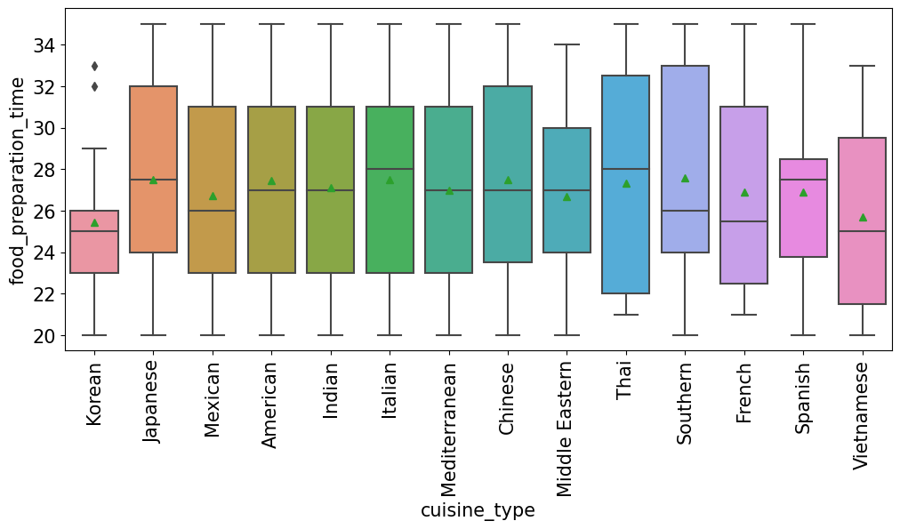

```python
# visualizing the relationship between cuisine_type and cost of the order
multi_boxplot(in_data=df, x_feature="cuisine_type", y_feature="food_preparation_time")
```

#### Observations:

- The top four (4) cusine types (American, Japanese, Italian, and Chinese) food preparation times for the most part cover the typical food preparation times for the other cuisine types. In other words, the food preparation time does not appear to be a strong indicator of impacting the number of orders.
- 75% of Korean food preparation times are 26 minutes or less; with a few outliers beyond Q3.

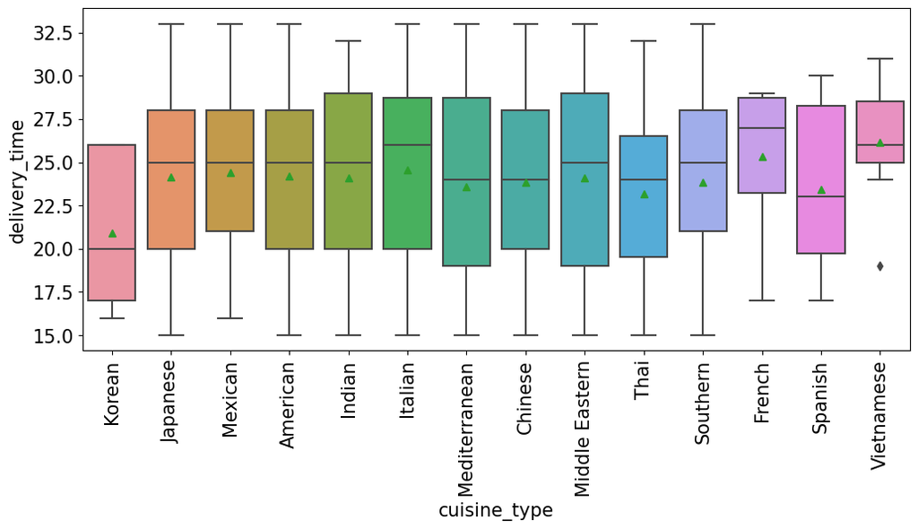

```python
# visualizing the relationship between cuisine_type and delivery time
multi_boxplot(in_data=df, x_feature="cuisine_type", y_feature="delivery_time")
```

#### Observations:

- The top four (4) cusine types (American, Japanese, Italian, and Chinese) delivery times are relatively similar and for the most part cover the typical delivery times for the other cuisine types. In other words, the delivery time does not appear to be a strong indicator of impacting the number of orders.
- 75% of Vietnamese orders takes around at least 24 minutes; with an outlier below Q1.

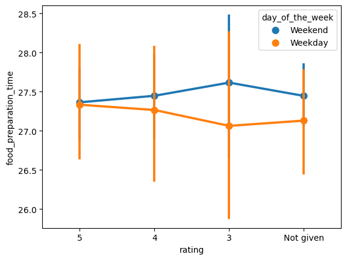

```python
# visualizing the relationship between rating and food preparation time
# pointplot
order_cols = ['5','4','3','Not given']

#create a pointplot; by default the estimator function used is mean.
sns.pointplot(data=df, x="rating", y="food_preparation_time", hue='day_of_the_week',order=order_cols);
```

#### Observations:

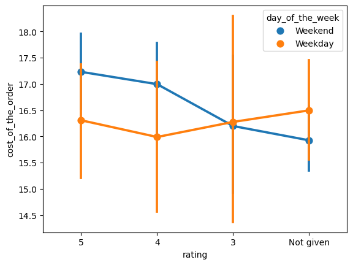

```python
# visualizing the relationship between rating vs food preparation time
#pointplot
order_cols = ['5','4','3','Not given']
sns.pointplot(data=df, x="rating", y="cost_of_the_order", hue='day_of_the_week',order=order_cols);
```

#### Observations:

- On the weekends, a slightly higher cost of order indicates an increased chance of receiving a higher rating.
- On the weekdays, the cost of the order does not show any significant evidence that it impacts the rating

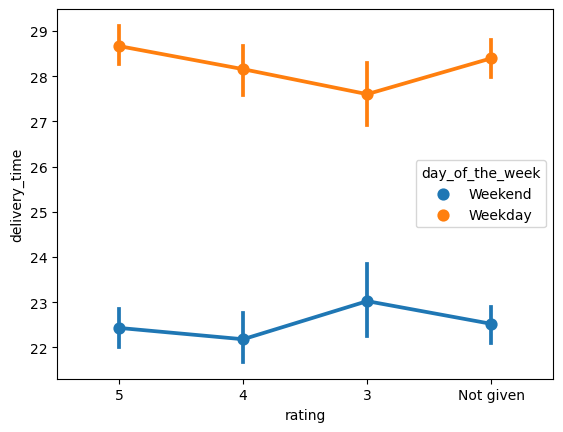

```python
# visualizing the relationship between rating vs cost of the order
#pointplot
order_cols = ['5','4','3','Not given']
sns.pointplot(data=df, x="rating", y="delivery_time", hue='day_of_the_week',order=order_cols);
```

#### Observations:

- The average weekend delivery times are approximately 6 minutes less than weekday delivery orders.
- The are no significant evidence that delivery times impact the rating.

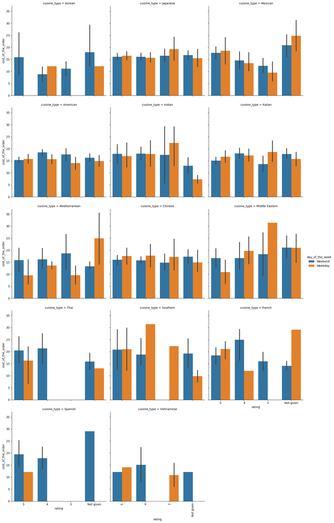

[output not shown]

```python
#create a catplot (bar graph) of rating vs cost_of_the_order. Do this for each cuistine type.

rating_order = ["5","4","3","Not given"]
catplot(in_data=df,
        x_feature='rating',
        y_feature='cost_of_the_order',
        in_hue='day_of_the_week',
        in_col='cuisine_type',
        in_kind='bar',
        in_xorder=rating_order)

# investigate the spanish cuisine data further. It's odd that there are very few weekday orders from the
# Spanish cuisine type.
df_copy = df[df['cuisine_type']=='Spanish']
df_copy
```

#### Observations:

- Insights for the top four cusine types (American, Japanese, Italian, and Chinese):
  > 1. For American cuisine, the cost of the order does not significantly impact the rating on the weekend or weekday. On the weekends, customers tend to pay more for American food.
  > 2. For Japanese cuisine, the cost of the order does not significantly impact the rating on the weekend or weekday.
  > 3. For Italian cuisine, the cost of the order does not significantly impact the rating on the weekend or weekday.
  > 4. For Chinese cuisine, the cost of the order does not significantly impact the rating on the weekend or weekday. On the weekdays, customers tend to pay more for Chinese food.
- Other insights:
  > 1. In the Middle Eastern cuisine, it appears that customers are paying top dollar, more than $30, on the weekday for a mediocore rating of 3.
  > 2. In the Thai cuisine, if a rating was given it was either a 5 or 4. Therefore, it's likely the Thai restaurants are well received and liked by customers.

### **Question 13:** The company wants to provide a promotional offer in the advertisement of the restaurants. The condition to get the offer is that the restaurants must have a rating count of more than 50 and the average rating should be greater than 4. Find the restaurants fulfilling the criteria to get the promotional offer. [3 marks]

```python
# Make a copy of the data because we're going to add an integer column for ratings that exist.
#
# Interpretation Assumption:
#    Assuming a rating count > 50 means that a restaurant must have more than 50 ratings from customers.
#       This does not mean the sum of the ratings for a restaurant must be more than 50. If this was the case
#       then the .count() would be changed to .sum()
#
# Cleanup Rule:
#    When value = 'Not given' insert a None value
#    Rationale: placing a None value will not positively nor negatively impact the rating total calculation
#

#make a copy of the dataframe
df_copy = df.copy()

#Create a new rating integer column and transform any Not given ratings to None.
#Decision made to leave original column just in case the original ratings column is needed again.
df_copy["rating_int"] = df["rating"].apply(
    lambda x: int(x) if x != "Not given" else None
)

# Total the ratings for each restaurant
df_rating_total = df_copy.groupby(['restaurant_name'])["rating_int"].count().to_frame().reset_index()
df_rating_total.columns = ['Restaurant Name', 'Rating Count']
df_rating_total.sort_values(by='Rating Count',ascending=False, inplace=True)

# Calculate the average rating for each restaurant
df_avg_rating = df_copy.groupby(['restaurant_name'])["rating_int"].mean().to_frame().reset_index()
df_avg_rating.columns = ['Restaurant Name', 'Average Rating']
df_avg_rating.sort_values(by='Average Rating',ascending=False, inplace=True)

# Now merge the two lists together using the restaurant name as key
merged_df = pd.merge(df_rating_total,df_avg_rating,on="Restaurant Name", how='inner')

# Filter the merged list only showing restaurants that have a rating count greater than 50
winners_df = merged_df[(merged_df['Rating Count']>50) & (merged_df['Average Rating']>4)]
winners_df
```

|  | Restaurant Name | Rating Count | Average Rating |
| --- | --- | --- | --- |
| 0 | Shake Shack | 133 | 4.28 |
| 1 | The Meatball Shop | 84 | 4.51 |
| 2 | Blue Ribbon Sushi | 73 | 4.22 |
| 3 | Blue Ribbon Fried Chicken | 64 | 4.33 |

#### Observations:

- There are four (4) restaurants that meet the promotion offer criteria are as follows;
  - Shake Shack
  - The Meatball Shop
  - Blue Ribbon Sushi
  - Blue Ribbon Fried Chicken

### **Question 14:** The company charges the restaurant 25% on the orders having cost greater than 20 dollars and 15% on the orders having cost greater than 5 dollars. Find the net revenue generated by the company across all orders. [3 marks]

```python
# Calculate the net revenue per order using the rules in Question 14
df_copy = df.copy()

#create a new column to store the net revenue per order based on the charge rates.
#if cost of order is greater than $20, then apply a 25% charge;
#else if cost of order is greater than $5 but less then $20, then apply a 15% charge;
# else if cost is less than $5, then no cost (may want to consider charging a flat fee)
df_copy['net_order_revenue'] = df_copy['cost_of_the_order'].apply(
    lambda cost: cost - cost*.25 if cost > 20 else cost-cost*.15 if cost > 5 else cost
)

total_net_revenues = df_copy['net_order_revenue'].sum()
print(f"Total Net Revenues: ${total_net_revenues:,.2f}")

# now sum the total net revenues made for each restaurant.
df_net_revenues = df_copy.groupby(['restaurant_name'])['net_order_revenue'].sum().to_frame().reset_index()
df_net_revenues.columns = ['Restaurant Name', 'Net Revenue']
df_net_revenues.sort_values(by='Net Revenue',ascending=False, inplace=True)

num_top_restaurants=12
print(f"\nTop {num_top_restaurants} restaurants generate {df_net_revenues.head(num_top_restaurants)['Net Revenue'].sum()/total_net_revenues*100:.2f}% of the total revenues.")
print(f"\nThe top {num_top_restaurants} Net Revenue generating restaurants")
df_net_revenues.head(num_top_restaurants)
```

```
Total Net Revenues: $25,148.52

Top 12 restaurants generate 50.62% of the total revenues.

The top 12 Net Revenue generating restaurants
```

|  | Restaurant Name | Net Revenue |
| --- | --- | --- |
| 136 | Shake Shack | 2875.92 |
| 153 | The Meatball Shop | 1725.38 |
| 21 | Blue Ribbon Sushi | 1543.49 |
| 20 | Blue Ribbon Fried Chicken | 1322.09 |
| 109 | Parm | 894.20 |
| 121 | RedFarm Broadway | 773.66 |
| 122 | RedFarm Hudson | 740.28 |
| 145 | TAO | 667.14 |
| 66 | Han Dynasty | 605.89 |
| 22 | Blue Ribbon Sushi Bar & Grill | 551.67 |
| 125 | Rubirosa | 519.64 |
| 143 | Sushi of Gari 46 | 510.37 |

### **Question 15:** The company wants to analyze the total time required to deliver the food. What percentage of orders take more than 60 minutes to get delivered from the time the order is placed? (The food has to be prepared and then delivered.) [2 marks]

```python
# Add a new column time_to_receive_order to keep track of whether the order took longer
# than 60 minutes to be delivered.
# True = if order took longer than 60 minutes; False=if order took 60 min or less
df['time_greater_than_hour'] = (df['food_preparation_time'] + df['delivery_time']) > 60

# Calculate the percentage of orders taking longer than 60 minutes
percentage_long_orders = (df['time_greater_than_hour'] == True).mean()*100

print(f"Percentage of orders taking more than 60 minutes: {percentage_long_orders:.2f}%")
```

```
Percentage of orders taking more than 60 minutes: 10.54%
```

#### Observations:

- Percentage of orders taking more than 60 minutes: **10.54%**

### **Question 16:** The company wants to analyze the delivery time of the orders on weekdays and weekends. How does the mean delivery time vary during weekdays and weekends? [2 marks]

```python
# Calculate the average delivery time for orders on the weekdays and weekends
df_avg_delivery_time = df_copy.groupby(['day_of_the_week'])['delivery_time'].mean().to_frame().reset_index()
df_avg_delivery_time.columns = ['Day Type', 'Total Delivery Time']
df_avg_delivery_time.sort_values(by='Total Delivery Time',ascending=True, inplace=True)
df_avg_delivery_time
```

|  | Day Type | Total Delivery Time |
| --- | --- | --- |
| 1 | Weekend | 22.47 |
| 0 | Weekday | 28.34 |

#### Observations:

- The average delivery time for the weekend is **22.47** minutes; which is close to 6 minutes faster than on the weekdays.

### Conclusion and Recommendations

### **Question 17:** What are your conclusions from the analysis? What recommendations would you like to share to help improve the business? (You can use cuisine type and feedback ratings to drive your business recommendations.) [6 marks]

### Conclusions:

The dataset from the FoodHub was analyzed to get a better understanding about the demand of the different restaurants and customer experiences. These insights can then be utilized to provide recommendations that will help enhance their customer experience; thus ultimately driving increased company revenues. With the help of descriptive analysis and visualizations, the following insights have been drawn:

[output not shown]

### Recommendations:

- **Cuisine Specific Promotion Strategies**
- American, Japanese, Italian, and Chinese Cuisines
- Introduce weekend promotions or exclusive menu items to capitalize on higher weekend orders.
- Implement targeted customer marketing campaigns to promote these cuisines or offer discounts.
- Implement exclusive marketing campaigns for the top 12 earning restaurants to help promote their specialty or seasonal items.
- To help improve weekday orders, run promotionals (reduced delivery fees, increase customer loyalty points, etc.) for Chinese restaurants since customers ordering Chinese food tend to pay more on the weekdays.
- To help improve weekend orders, run promotionals for American restaurants since customers ordering American food tend to pay more on the weekends.
- Explore opportunities for upselling or cross selling to increase the average order size; thus increasing the net revenue per order.
- Middle Eastern Cuisine
- Leverage high weekday average cost of orders:
- Analyze customer feedback to identify areas for improvement and if necessary provide this information to the impacted Middle Eastern restaurants.
- Recommend adjusting pricing or offering weekday specials to help improve ratings.
- For the customers who provided three star ratings in this area, provide targeted customer discount incentives to improve chances of repeat business.
- Thai Cuisine:
- Leverage the positive customer sentiment for Thai cuisine:
- Send targeted customer marketing promotions, to those ordering in the top four cuisines that are not ordering Thai.
- Work with local Thai restaurants to expand or enhance the Thai menu to help expand its customer base.
- **Customer Loyalty Program**
- Develop a customer loyalty program that provides incentives to repeat customers. Incentivies may include discounts, exclusive deals, loyalty points, etc.
- Offer customer loyalty points for every review provided. Customer loyalty points can be redeemed for discounts.
- Using order history, create personalized promotions based on customer ordering preferences.
- **Delivery Driver Loyalty Program**
- Create a delivery driver loyalty program to build a strong base of long-term delivery drivers.
- Add delivery driver incentives for weekday deliveries to help reduce the overall weekday delivery times.
- **Rating Improvement Strategies**
- Provide customers with incentives (loyalty points, discounts, etc.) to provide ratings and reviews.
- Provide restaurants with customer review feedback summaries to help restaurants improve overall ratings.
- Verify with Foodhub development team that the application is allowing and/or capturing rating values of one (1) and two (2).
- **Improved Data Analytics**
- Recommend procuring funds to gather day and time information for all time fields; enabling detailed analytics on day of week and time of day.
- Recommend procuring funds to gather detailed driver delivery information (e.g., number of pickups, $ of on-time deliveries, and delivery driver ratings). Delivery driver data could be used to help improve loyalty among drivers; which will result in improved pick-up times and customer satisfaction.